# Monophonic music transcription

### github repo

Please visit https://github.com/OliverIgnetik/engn4200_thesis to see all the resources collected for this project aswell as a detailed research log.

```python
%matplotlib inline
from pathlib import Path
import pandas as pd
import numpy as np, scipy, matplotlib.pyplot as plt, sklearn, IPython.display as ipd
import librosa, librosa.display
import warnings
warnings.filterwarnings('ignore')
```

# Introduction

This report compares three methods for transcribing music using a sample from the MAPS database. The three methods compared are :

1. Non-negative Matrix Factorization (NMF)
2. Autocorrelation method
3. CEPSTRUM method

This sample recording is a chromatic scale played on a Bechstein D 280 in a concert hall recording environment retrieved from the MAPS database. [1] Ground truths are recorded using the disklavier technology which records pitch, onset and offset times of each note played.

**MAPS database url**: http://www.tsi.telecom-paristech.fr/aao/en/category/database/

## LibROSA package

**LibROSA github page** : https://librosa.github.io/librosa/

LibROSA is a python package for music and audio analysis. It provides the building blocks necessary to create music information retrieval systems. It has many useful features such as peak picking algorithms, factorization methods, spectrogram computation and beat onset calculation. [2]

# Import Data

```python
p = Path('/Users/olli/Desktop/engn4200_thesis')
dataset = 'resources'
sub_dir = 'software'
file = 'MAPS_ISOL_CH0.3_F_AkPnBcht.wav'
p = p/dataset/sub_dir/file
p
```

```
WindowsPath('/Users/olli/Desktop/engn4200_thesis/resources/software/MAPS_ISOL_CH0.3_F_AkPnBcht.wav')
```

```python
# load a scale
x, sr = librosa.load(p, sr=44100)
```

```python
# extract a segment
initial_time = 15
end_time = 18
ipd.Audio(x[initial_time*sr:end_time*sr], rate=sr)
```

[interactive chart not shown]

```python
# extract a segment
x = x[initial_time*sr:end_time*sr]
```

```python
N = len(x)
print(N,'number of samples')
```

```
132300 number of samples
```

```python
# extract the relevant ground truths
ground_truths = pd.read_csv('MAPS_ISOL_CH0.3_F_AkPnBcht.txt', sep='\t')
mask = np.logical_and(ground_truths['OnsetTime']>=initial_time, ground_truths['OnsetTime']<=end_time)
ground_truths_sample = ground_truths[mask][['OnsetTime','MidiPitch']]
ground_truths_sample.reset_index(inplace=True)
ground_truths_sample.drop(columns=['index'],inplace=True)
ground_truths_sample
```

|  | OnsetTime | MidiPitch |
| --- | --- | --- |
| 0 | 15.0705 | 68 |
| 1 | 15.3805 | 69 |
| 2 | 15.6905 | 70 |
| 3 | 16.0005 | 71 |
| 4 | 16.3105 | 72 |
| 5 | 16.6205 | 73 |
| 6 | 16.9305 | 74 |
| 7 | 17.2405 | 75 |
| 8 | 17.5505 | 76 |
| 9 | 17.8606 | 77 |

```python
# extract unique MIDI notes
unique_midi = np.unique(ground_truths_sample.MidiPitch)
# how many unique notes?
number_notes = len(unique_midi)
number_notes
```

```
10
```

# Exploratory Data Analysis

As in other audio-related applications, the most popular tool for describing the time-varying energy across different frequency bands is the short-time Fourier transform (STFT), which, when visualized as its magnitude, is known as the spectrogram. It is defined mathematically as:

$$ X(t,k) = \sum_{n=0}^{N-1} w[n] \cdot x[n+t+N/2]\cdot e^{-j2 \pi \frac{kn}{N}} $$

They are computed over k frequency basis vectors and t time frames determined by the hop length. Usually a hanning window ($w[n]$) is used to smooth out discontinuties.

A Short Time Fourier Transform (STFT) will be used in the NMF approach. However, the time resolution of the spectrogram must be balanced with the frequency resolution. [3]

```python
# we need semitone resolution
b,c = librosa.note_to_hz(['B3','C4'])
semitone = np.round(c-b,2)
print('semitone resolution:',semitone,'Hz')
print('FFT needs', int(sr/semitone), 'samples')
```

```
semitone resolution: 14.68 Hz
FFT needs 3004 samples
```

```python
print('time resolution:', int(sr/semitone)/sr,'s')
```

```
time resolution: 0.06811791383219955 s
```

```python
# stft with default hop length and window size

sr = 44100 # 44.1kHz sampling frequency
hop_length = 512  # spacing in between dfts
n_fft = 3004 # window size

S = librosa.stft(x,hop_length=hop_length, n_fft=n_fft)
print(S.shape)
```

```
(1503, 259)
```

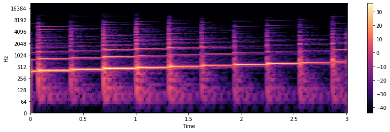

```python
# Use of the db scale to replicate the way humans interpret sound
S_db = librosa.amplitude_to_db(abs(S))
plt.figure(figsize=(14, 4))
_ = librosa.display.specshow(S_db, sr=sr, x_axis='time', y_axis='log')
_ = plt.colorbar()
```

# Non-negative Matrix Factorization (NMF) approach

NMF is an algorithm that factorizes a nonnegative matrix, $X$, into a product of two nonnegative matrices, $W$ and $H$. It is an unsupervised iterative algorithm that minimizes a distance between $X$ and the product $W \times H$:

$$ \min_{W, H} d(X, W \times H) $$

If $X$ has dimensions $M$ by $N$, then $W$ will have dimensions $M$ by $R$, and $H$ will have dimensions $R$ by $N$, where inner dimension $R$ is the *rank* or *number of components* of the decomposition. When applied to a musical signal, the NMF can decompose the signal into separate note events. Therefore, NMF is quite useful and popular for tasks such as transcription and source separation.The input, $X$, is often a magnitude spectrogram. In such a case, the columns of $W$ represent spectra of note events, and the rows of $H$ represent temporal envelopes of the same note events. [4]

```python
# seperate the harmonic STFT into magnitude and phase
# NMF will only factorize the magnitude part of the STFT
X, X_phase = librosa.magphase(S)

# NMF extracts unique events
n_components = number_notes

# NMF decomposition
W, H = librosa.decompose.decompose(X,
                                   n_components=n_components,
                                   sort=True)

print('Shape of Dictionary and Activation matrices')
print('-'*60)
print(W.shape)
print(H.shape)
```

```
Shape of Dictionary and Activation matrices
------------------------------------------------------------
(1503, 10)
(10, 259)
```

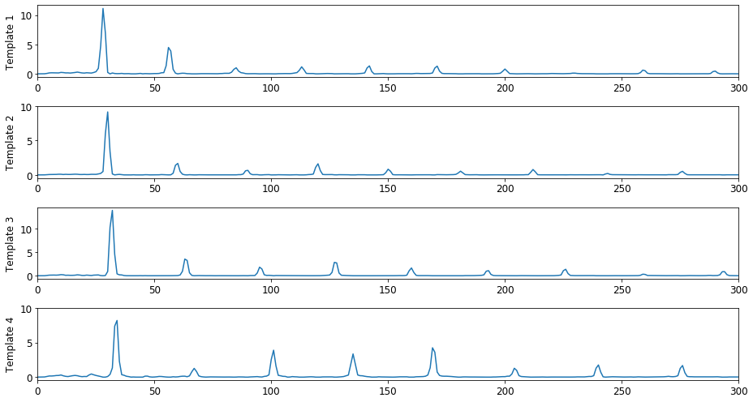

```python
# show some components
plt.figure(figsize=(13, 7))
# take the logarithm of each spectral component
for n in range(4):
    plt.subplot(4, 1, n+1)
    plt.plot(W[:,n])
    plt.xticks(fontsize=12)
    plt.xlim(0, 300)
    plt.ylabel(f'Template {n+1}', fontsize=12)
    plt.yticks(np.arange(0,15,5), fontsize=12)

plt.tight_layout()
plt.show()
```

## f0 estimation - dft analysis

Most musical instruments—including string-based instruments such as guitars, violins, and pianos, as well as instruments based on vibrating air columns such as flutes, clarinets, and trumpets—are explicitly constructed to allow performers to produce sounds with easily controlled, locally stable fundamental periods. Such a signal is well described as a harmonic series of sinusoids at multiples of a fundamental frequency, and results in the perception of a musical note (a single perceived event) at a clearly defined pitch in the mind of the listener. With the exception of unpitched instruments like drums, and a few inharmonic instruments such as bells, the periodicity of individual musical notes is rarely ambiguous, and thus equating the perceived pitch with fundamental frequency is common. [5]

One way to do this is by computing the difference between peaks in the power spectrum.

```python
# extract frequency from component dfts
def estimate_pitch(power_spectrum,fmin=20,fmax=4300,n_fft=3004,sr=44100):
    # parameters for peak picker
    # peak is picked based on satisfying these conditions:
    # x[n] == max(x[n - pre_max:n + post_max])
    # x[n] >= mean(x[n - pre_avg:n + post_avg]) + delta
    # n - previous_n > wait
    pre_max = 10
    post_max = 10
    pre_avg = 10
    post_avg = 10
    delta = 0.5
    wait = 10
    # evaluate maximum peaks for each power spectrum
    peaks = librosa.util.peak_pick(power_spectrum,
                                   pre_max,
                                   post_max,
                                   pre_avg,
                                   post_avg,
                                   delta,
                                   wait)

    # we only need 3 harmonics to calculate the f0
    peaks = peaks[:5]
    diffs = []
    # find the difference in between each of the peaks
    for j in range(len(peaks)-1):
        diffs.append(peaks[j+1]-peaks[j])

    # find the average of the differences which corresponds to the fundamental frequency
    i_index = np.floor(np.average(diffs))
    # find the frequency
    f0 = sr*i_index/n_fft
    return f0
```

```python
# find the fundamental frequency
f0_freq = []
for n in range(n_components):
    power_spectrum = W[:,n]
    freq_est = estimate_pitch(power_spectrum)
    f0_freq.append(freq_est)

MIDI_nums = np.around(librosa.hz_to_midi(f0_freq))
print('MIDI estimates')
print('-'*60)
MIDI_nums
```

```
MIDI estimates
------------------------------------------------------------
```

```
array([68., 69., 70., 71., 72., 73., 74., 75., 76., 77.])
```

## Note onsets

The notes display characteristic curves (attack, sustain, decay, release) for piano notes as can be seen in the graphs below.

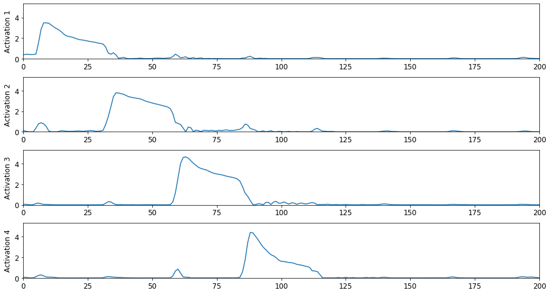

```python
# show some activations for different notes
plt.figure(figsize=(13, 7))
for n in range(4):
    plt.subplot(4, 1, n+1)
    plt.plot(H[n])
    plt.ylim(0, H.max())
    plt.yticks(fontsize=12)
    plt.xticks(fontsize=12)
    plt.xlim(0, 200)
    plt.ylabel('Activation %d' % (n+1), fontsize=12)

plt.tight_layout()
plt.show()
```

```python
# estimating onset times from activation components
hop_length = 512
attack_frames = 3

# peak picking parameters
# peak is picked based on satisfying these conditions:
# x[n] == max(x[n - pre_max:n + post_max])
# x[n] >= mean(x[n - pre_avg:n + post_avg]) + delta
# n - previous_n > wait
pre_max = 10
post_max = 10
pre_avg = 50
post_avg = 50
delta = 2
wait = 10

onset_times = []

for H_n in H:
    peak_frame_no = librosa.util.peak_pick(H_n,
                                           pre_max,
                                           post_max,
                                           pre_avg,
                                           post_avg,
                                           delta,
                                           wait)
    # account for attack phase in note
    peak_frame_no -= attack_frames
    # convert from frame number to sample number
    samples_no = peak_frame_no*hop_length
    # convert from samples to time and append to onset times array
    onset_times.append(float(librosa.samples_to_time(samples_no, sr=sr)+initial_time))

print('Onset times for each note')
print('-'*60)
print(onset_times)
```

```
Onset times for each note
------------------------------------------------------------
[15.058049886621315, 15.38312925170068, 15.696598639455782, 15.986848072562358, 16.30031746031746, 16.6021768707483, 16.93886621315193, 17.240725623582765, 17.530975056689343, 17.844444444444445]
```

```python
# NMF transcription dataframe
NMF_transcription = pd.DataFrame(list(zip(onset_times,MIDI_nums)))
NMF_transcription.columns = ground_truths_sample.columns
NMF_transcription
```

|  | OnsetTime | MidiPitch |
| --- | --- | --- |
| 0 | 15.058050 | 68.0 |
| 1 | 15.383129 | 69.0 |
| 2 | 15.696599 | 70.0 |
| 3 | 15.986848 | 71.0 |
| 4 | 16.300317 | 72.0 |
| 5 | 16.602177 | 73.0 |
| 6 | 16.938866 | 74.0 |
| 7 | 17.240726 | 75.0 |
| 8 | 17.530975 | 76.0 |
| 9 | 17.844444 | 77.0 |

# Autocorrelation/CEPSTRUM segmentation approach

## Onset Detection and segmentation

A widely used approach to onset detection in the frequency domain is the spectral flux, where changes of pitch and timbre are detected by analyzing the signal’s short-time spectrum. [5]

The LibROSA library has an onset detection method which determines onsets of notes by calculating the change in spectral energy and calculating the resulting onset curve shown below.

The onsets can then be used to segment the signal between different note onsets.

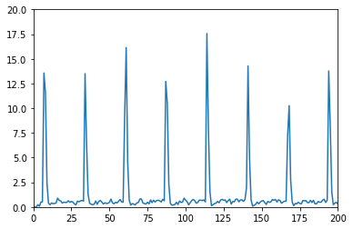

```python
# plot the onset envelope that will be used in the onset detect method
# SPECTRAL FLUX is used to find the onset sample numbers
# thus a dft is needed and we need to specify the hop length
hop_length = 512

# Find the onsets using spectral flux
onset_env = librosa.onset.onset_strength(x,
                                         sr=sr,
                                         hop_length=hop_length)

# plot the onset envelope
plt.plot(onset_env);
plt.ylim(0,20);
plt.xlim((0,200));
```

```python
# find the onsets
# hop length of 512 gives 174 frames
hop_length = 512

# peak is picked based on satisfying these conditions:
# x[n] == max(x[n - pre_max:n + post_max])
# x[n] >= mean(x[n - pre_avg:n + post_avg]) + delta
# n - previous_n > wait

onset_samples = librosa.onset.onset_detect(x,
                                           sr=sr,
                                           units='samples',
                                           hop_length=hop_length,
                                           pre_max=20,
                                           post_max=20,
                                           pre_avg=50,
                                           post_avg=50,
                                           delta=0.02,
                                           wait=0)

# define onset_boundaries for segmenting audio
onset_boundary_samples = np.concatenate([onset_samples, [N]])

# for mir_eval calculation
onset_times = librosa.samples_to_time(onset_samples, sr=sr)
# add the initial time
onset_times += initial_time

print('Onset times')
print('-'*60)
print(onset_times)
```

```
Onset times
------------------------------------------------------------
[15.08126984 15.39473923 15.70820862 16.01006803 16.32353741 16.6370068
 16.95047619 17.2523356  17.56580499 17.87927438]
```

## f0 estimation

### cepstrum method

A cepstrum is the result of taking the inverse Fourier transform (IFT) of the logarithm of the estimated spectrum of a signal. It was first defined in a paper by Tukey and Healey in 1963. Cepstrum pitch determination is effective at finding periodics in discrete fourier transforms. It is defined mathematically as :

$$ power\:cepstrum= |\mathfrak{F}^{-1}\{log(|\mathfrak{F}\{f(t)\}|^{2})\}|^{2}$$

The independent variable of the cepstral graph is called the **quefrency**. Lower quefrencies correspond to higher frequncies. It is a common industry standard in pitch determination algorithms. [6]

### autocorrelation method

The autocorrelation of a discrete signal is mathematically defined as :

$$ f(\tau) = \sum_{n=t+1}^{t+W}x[n]x[n+\tau] $$

The highest peak in the autocorrelation function corresponds to the fundamental frequency of the sound signal. It is often used in the YIN algorithm as a first step in determining fundamental frequencies in sound signals. [7]

In librosa a damped autocorrelation function is used which improves the accuracy of the algorithm by ensuring that the first relative maximum will have the highest peak.

```python
from scipy.fftpack import fft, ifft

def estimate_pitch(segment, sr, f_min=20, f_max=4200, method='auto'):

    # autocorrelation method
    if method == 'auto':
        # Compute autocorrelation of input segment.
        r = librosa.autocorrelate(segment)
        # Define lower and upper limits for the autocorrelation argmax.
        i_min = sr/f_max
        i_max = sr/f_min
        r[:int(i_min)] = 0
        r[int(i_max):] = 0
        # Find the location of the maximum autocorrelation.
        i = r.argmax()
        f0 = float(sr)/i
        return f0

    # cepstrum method
    elif method == 'cepstrum':
        # Compute power spectrum
        power_spectrum = np.abs(fft(segment))**2
        # compute cepstrum
        CEPSTRUM = np.abs(ifft(np.log10(power_spectrum)))**2
        # set indexes
        start = int(sr/f_max)
        end = int(sr/f_min)
        # narrow cepstrum to frequency range of interest
        CEPSTRUM = CEPSTRUM[start:end]
        peak_ix = CEPSTRUM.argmax()
        # find the fundamental frequency
        f0 = sr/(start + peak_ix)
        return f0
```

```python
# sine tone for transcription playback
def generate_sine(f0, sr, n_duration):
    # set a duration time for the tone
    n = np.arange(n_duration)
    return 0.2*np.sin(2*np.pi*f0*n/float(sr))
```

```python
# calculate the pitch estimations for the two different methods
MIDI_nums_auto = []
MIDI_nums_cepstrum =[]
playback = []

for i in range(len(onset_boundary_samples)-1):
        # slice audio segments
        n0 = onset_boundary_samples[i]
        n1 = onset_boundary_samples[i+1]
        segment_duration = n1 - n0

        # estimate pitch for segment using autocorrelation
        f0 = estimate_pitch(x[n0:n1], sr,method='auto')
        MIDI_nums_auto.append(int(librosa.hz_to_midi(f0)))
        playback.append(generate_sine(f0,sr,segment_duration))


        # estimate pitch for segment using cepstrum
        f0 = estimate_pitch(x[n0:n1], sr,method='cepstrum')
        MIDI_nums_cepstrum.append(int(librosa.hz_to_midi(f0)))

# concatenate sine tones for playback format
playback = np.concatenate(playback)
```

```python
# store autocorrelation results in a dataframe
auto_transcription = pd.DataFrame(list(zip(onset_times,MIDI_nums_auto)))
auto_transcription.columns = ground_truths_sample.columns
auto_transcription
```

|  | OnsetTime | MidiPitch |
| --- | --- | --- |
| 0 | 15.081270 | 68 |
| 1 | 15.394739 | 69 |
| 2 | 15.708209 | 70 |
| 3 | 16.010068 | 71 |
| 4 | 16.323537 | 72 |
| 5 | 16.637007 | 73 |
| 6 | 16.950476 | 74 |
| 7 | 17.252336 | 75 |
| 8 | 17.565805 | 76 |
| 9 | 17.879274 | 77 |

```python
# store CEPSTRUM results in a dataframe
CEPSTRUM_transcription = pd.DataFrame(list(zip(onset_times,MIDI_nums_cepstrum)))
CEPSTRUM_transcription.columns = ground_truths_sample.columns
CEPSTRUM_transcription
```

|  | OnsetTime | MidiPitch |
| --- | --- | --- |
| 0 | 15.081270 | 71 |
| 1 | 15.394739 | 70 |
| 2 | 15.708209 | 96 |
| 3 | 16.010068 | 71 |
| 4 | 16.323537 | 72 |
| 5 | 16.637007 | 73 |
| 6 | 16.950476 | 75 |
| 7 | 17.252336 | 75 |
| 8 | 17.565805 | 76 |
| 9 | 17.879274 | 77 |

```python
# play back the audio for the autocorrelation method
ipd.Audio(playback, rate=sr)
```

[interactive chart not shown]

# Evaluation of different methods

mir_eval is a python package that can be used to evaluate the accuracy of transcription algorithms with metrics other then accuracy which is often not correlated with human experience. [9] A link to the repository can be found here: http://craffel.github.io/mir_eval/

```python
# mir eval is used to evaluate accuracy and other standardized metrics
# that are used by MIREX
import mir_eval
```

```python
# place values in appropriate format
ref_time = ground_truths_sample.OnsetTime.values
ref_freqs = librosa.midi_to_hz(ground_truths_sample.MidiPitch.values)

# NMF values
NMF_time = NMF_transcription.OnsetTime.values
NMF_freqs = librosa.midi_to_hz(NMF_transcription.MidiPitch.values)

# auto_correlation values
auto_time = auto_transcription.OnsetTime.values
auto_freqs = librosa.midi_to_hz(auto_transcription.MidiPitch.values)

# cepstrum values
cepstrum_time = CEPSTRUM_transcription.OnsetTime.values
cepstrum_freqs = librosa.midi_to_hz(CEPSTRUM_transcription.MidiPitch.values)

# evaluate the quality of the transcription
print('NMF approach accuracy metrics')
print('-'*60)
print(mir_eval.melody.evaluate(ref_time,ref_freqs,NMF_time,NMF_freqs))
print('-'*60)
print('Autocorrelation approach accuracy metrics')
print('-'*60)
print(mir_eval.melody.evaluate(ref_time,ref_freqs,auto_time,auto_freqs))
print('-'*60)
print('CEPSTRUM approach accuracy metrics')
print('-'*60)
print(mir_eval.melody.evaluate(ref_time,ref_freqs,cepstrum_time,cepstrum_freqs))
```

```
NMF approach accuracy metrics
------------------------------------------------------------
OrderedDict([('Voicing Recall', 0.9090909090909091), ('Voicing False Alarm', 0.0), ('Raw Pitch Accuracy', 0.9090909090909091), ('Raw Chroma Accuracy', 0.9090909090909091), ('Overall Accuracy', 0.9090909090909091)])
------------------------------------------------------------
Autocorrelation approach accuracy metrics
------------------------------------------------------------
OrderedDict([('Voicing Recall', 1.0), ('Voicing False Alarm', 0.0), ('Raw Pitch Accuracy', 1.0), ('Raw Chroma Accuracy', 1.0), ('Overall Accuracy', 1.0)])
------------------------------------------------------------
CEPSTRUM approach accuracy metrics
------------------------------------------------------------
OrderedDict([('Voicing Recall', 1.0), ('Voicing False Alarm', 0.0), ('Raw Pitch Accuracy', 0.45454545454545453), ('Raw Chroma Accuracy', 0.45454545454545453), ('Overall Accuracy', 0.45454545454545453)])
```

## Remarks

We can see that the autocorrelation method performs best overall but is only applicable to single note melodies. The NMF approach however can be extended to polyphonic cases, which is why this approach will be pursued in the future.

# Future Work

The outcomes of this report are only applicable to monophonic music. Ultimately the goal of this research project is to explore polpyhonic music. There are two promising avenues that will be pursued in the future :

- NMF approaches
- Neural Network (NN) approaches

An preliminary attempt at using NN [10] to solve polyphonic music can be found here :

https://gist.github.com/OliverIgnetik/f502393b6049cdd4fee358baf3cc89c7 [*HTML jupyter notebook format*]

However, in order to improve the **NN** model, future work is needed:

- Solve the class imbalance / sparsity problem. There are many inactive notes in every frame. A more appropriate evaluation metric is needed such as weighted class accuracy.
- Long Short-Term Models for NN to learn temporal dependencies in the model.
- Investigate using multiple spectrograms as input to the model.

The **NMF** approach may be improved by exploring :

- Hidden Markov Models (HMMs) to model temporal dependencies between note transitions
- Investigating source separation literature to help with disentangling energy from multiple pitches

Finally some work has been done to characterize chords or groups of notes by features [10] such as spectral entropy and chroma characeteristics which can be found here :

https://gist.github.com/OliverIgnetik/91549a6d75727ff932138e2f6a1e1aee [*HTML jupyter notebook format*]

The aim is that by characterizing groups of notes by certain characteristics the total number of possible choices can be reduced and may be incorporated in designing the observation matrix for a HMM model. [11]

# References

[1] V. Emiya, R. Badeau and B. David, Multipitch estimation of piano sounds using a new probabilistic spectral smoothness principle, IEEE Transations on Audio, Speech and Language Processing, (to be published)

[2] McFee, Brian, Colin Raffel, Dawen Liang, Daniel PW Ellis, Matt McVicar, Eric Battenberg, and Oriol Nieto. "librosa: Audio and music signal analysis in python." In Proceedings of the 14th python in science conference, pp. 18-25. 2015.

[3] E. Benetos, S. Dixon, Z. Duan, S. Ewert, “Automatic Music Transcription”, in IEEE SPS Journal Vol. 36 January

[4] P. Smaragdis and J. C. Brown, “Non-negative matrix factorization for polyphonic music transcription,” in Proc. IEEE Workshop Applications Signal Processing Audio and Acoustics, 2003, pp. 177–180.

[5] M. Müller, D. P. Ellis, A. Klapuri, and G. Richard, “Signal processing for music analysis,” IEEE J. Sel. Topics Signal Process., vol. 5, no. 6, pp. 1088–1110, 2011.

[6] A. Wszeborowska, Anna Wszeborowska - Music transcription with Python. 2016.

[7] National University of Singpaore, X. Chang, An Introduction to pitch tracking and the YIN algorithm, 2019

[8] Colin Raffel, Brian McFee, Eric J. Humphrey, Justin Salamon, Oriol Nieto, Dawen Liang, and Daniel P. W. Ellis, “mir_eval: A Transparent Implementation of Common MIR Metrics”, Proceedings of the 15th International Conference on Music Information Retrieval, 2014.

[9] L. Li, I. Ni and L. Yang, "Music Transcription Using Deep Learning", Stanford University, 2019.

[10] Y. Wang, "Lecture 3 : Perceptual Features", NUS, 2019.

[11] Rabiner et al, 1986, “An Introduction to Hidden Markov Models”, IEEE ASSP Magazine January 1986